# Travail pratique 3 - Analytique prescriptive

Équipe 8: **MARTIN, SABRINA** (Matricule: 537381603) **KEITA, MAHOMET LIMENIA JEAN-YVES** (Matricule: 537175293)

2025-11-19

# 1 - Programmation mathématique (investissements)

Chargement des librairies tidyverse (Wickham et al. 2019) & CVXR (Fu, Narasimhan, and Boyd 2020) qui seront utilisées pour répondre à la question.

```r
library(tidyverse)
library(CVXR)
```

## Introduction au problème

Nous avons 550 000$ disponibles à investir au début de l’an 1 (P3 / C2). L’objectif est de maximiser le montant en main à la fin de l’an 8 (P5). Il y a 4 options d’investissements parmi lesquelles nous devons choisir, et nous devrons aussi choisir quel montant investir dans chaque option:

1. un investissement d’une durée (horizon) de 3 ans (P1) à 4 % (P2), disponible au début de l’an 3 (P4);
2. un investissement d’une durée de 5 ans (P1) à 5 % (P2), disponible au début de l’an 1 (P4);
3. un investissement d’une durée de 3 ans (P1) à 5 % (P2), disponible au début de l’an 6 (P4);
4. des investissements d’une durée de 2 ans (P1) à 2 % (P2), disponible au début de l’an 1, de l’an 3, de l’an 5 et de l’an 7 (P4). (voir comme 4 placements différents)

En réalité, comme l’option 4 contient 4 différents investissements, il faut plutôt considérer un total de 7 options d’investissements disponibles (P6). Aucun argent ne peut être emprunté pour atteindre l’objectif (C1).

Pour aider à visualiser les options de placement et leur horizons, voici un graphique avec les années de début et de fin de chaque option.

```r
placements_horizon <- data.frame(
  Placements = paste0("Z_", 1:7),
  Debut = c(3, 1, 6, 1, 3, 5, 7),
  Duree = c(3, 5, 3, 2, 2, 2, 2))

placements_horizon <-
  placements_horizon %>%
  mutate(Fin = c(Debut + Duree))

placements_horizon
```

```
##   Placements Debut Duree Fin
## 1        Z_1     3     3   6
## 2        Z_2     1     5   6
## 3        Z_3     6     3   9
## 4        Z_4     1     2   3
## 5        Z_5     3     2   5
## 6        Z_6     5     2   7
## 7        Z_7     7     2   9
```

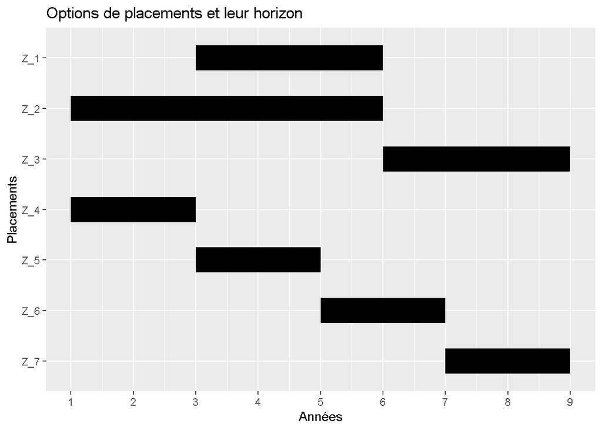

```r
placements_horizon %>%
  ggplot() +
  geom_segment(aes(
    x = Debut,
    xend = Fin,
    y = Placements,
    yend = Placements
    ),
    linewidth = 10) +
  scale_y_discrete(limits = rev) +
  scale_x_continuous(limits = c(1, 9), breaks = c(1:9)) +
  labs(
    title = "Options de placements et leur horizon",
    x = "Années",
    y = "Placements"
  )
```

## 1.1 - Modélisation

Définir les paramètres, variables et contraintes du modèle. Pour aider à résoudre le problème, deux variables de décision sont nécessaires: l’argent investi dans chaque option de placement (V2), ainsi que l’argent disponible à chaque période ou le flux monétaire (V1 / C3).

```r
#P1: horizon de chaque option, dans l'ordre
pDuree <- c(3, 5, 3, 2, 2, 2, 2)
#P2: rendement de chaque option, dans l'ordre
pRendement <- c(1.04, 1.05, 1.05, 1.02, 1.02, 1.02, 1.02)
#P3: budget initial au début de l'an 1
pBudgetmax <- 550000
#P4: l'année que chaque placement débute, dans l'ordre
pDebut <- c(3, 1, 6, 1, 3, 5, 7)
#P5: horizon total
pDureeMax <- 8
#P6: nombre de placements différents
pNbOptions <- 7

#V1: argent disponible au début de chaque période (flux)
vY <- Variable(pDureeMax + 1, name = "Y")

#V2: combien investir dans chaque option de placement
vZ <- vstack(
  Variable(name = "Z_1"), #placement 1
  Variable(name = "Z_2"), #placement 2
  Variable(name = "Z_3"), #placement 3
  Variable(name = "Z_4"), #placement 4 à l'an 1
  Variable(name = "Z_5"), #placement 4 à l'an 3
  Variable(name = "Z_6"), #placement 4 à l'an 5
  Variable(name = "Z_7")  #placement 4 à l'an 7
)

#Contraintes
constraints <- list()

#C1: argent disponible et argent investi ne doit pas être négatif, aucun emprunt
constraints <- c(constraints, vY >= 0, vZ >= 0)

#C2: argent disponible au début période 1 est le budget initial
constraints <- c(constraints, vY[1] == pBudgetmax)

#C3: flux monétaire au début de chaque période
#argent restant de la période précédente s'il n'a pas été utilisé + les entrées - les sorties
constraints <- c(constraints,
  vY[2] == vY[1] - (vZ[2] + vZ[4]),                   #an 2, an 1 moins les placements faits an 1, aucun nouveau
  vY[3] == vY[2] + vZ[4] * pRendement[4] - (vZ[1] + vZ[5]),         #an 3, un placement termine, deux débutent
  vY[4] == vY[3],                                                   #an 4, aucun placement ne termine ni débute
  vY[5] == vY[4] + vZ[5] * pRendement[5] - vZ[6],                   #an 5, un placement termine, un débute
  vY[6] == vY[5] + vZ[1] * pRendement[1] + vZ[2] * pRendement[2] - vZ[3], #an 6, 2 se terminent, un débute
  vY[7] == vY[6] + vZ[6] * pRendement[6] - vZ[7],                   #an 7, un placement termine, un débute
  vY[8] == vY[7],                                                   #an 8, aucun placement ne termine ni débute
  vY[9] == vY[8] + vZ[3] * pRendement[3] + vZ[7] * pRendement[7]    #an 9, deux placements terminent (fin an 8)
)

#Fonction objectif
#maximiser l'argent disponible au début de l'an 9, c'est à dire l'argent disponible à la fin de l'an 8
objective <- Maximize(vY[9])

# modèle mathématique
problem <- Problem(objective, constraints)

# Résoudre avec le solveur
result <- psolve(problem, solver = "GLPK_MI")
```

## 1.2 Résolution

Consulter la solution trouvée par le solveur et le statut du solveur. La solution trouvée est optimale; elle maximise le montant en main à la fin de l’an 8 (argent investi + intérêts générés). Consulter le résultat de la fonction objectif.

```r
#statut du solveur
cat('Statut retourné par le solveur:',
    result$status,
    '\n')
```

```
## Statut retourné par le solveur: optimal
```

```r
#résultat de la fonction objectif
cat(sprintf("Valeur de la fonction objectif: %.2f\n", result$value))
```

```
## Valeur de la fonction objectif: 612612.00
```

Consulter le détail de la solution pour chaque variable:

```r
#argent investi dans chaque option de placement
solution <-
  tibble(variable = map(CVXR::variables(vZ), "name"),
         valeur = round(result$getValue(vZ), 2)) %>%
  mutate(variable = as.character(variable))

solution
```

```
## # A tibble: 7 × 2
##   variable valeur[,1]
##   <chr>         <dbl>
## 1 Z_1          561000
## 2 Z_2               0
## 3 Z_3          583440
## 4 Z_4          550000
## 5 Z_5               0
## 6 Z_6               0
## 7 Z_7               0
```

```r
#flux monétaire
solution2 <-
  tibble(variable = map(CVXR::variables(vY), "name"),
         valeur = round(result$getValue(vY), 2)) %>%
  mutate(variable = as.character(variable)) %>%
  mutate(année = c(1:9), .after = variable)

solution2
```

```
## # A tibble: 9 × 3
##   variable année valeur[,1]
##   <chr>    <int>      <dbl>
## 1 Y            1     550000
## 2 Y            2          0
## 3 Y            3          0
## 4 Y            4          0
## 5 Y            5          0
## 6 Y            6          0
## 7 Y            7          0
## 8 Y            8          0
## 9 Y            9     612612
```

La solution optimale trouvée par le solveur est donc d’investir la totalité du 550 000 dollars dans le placement Z_4 à l’an 1, puis à son échéance à l’an 3 (durée 2 ans), de réinvestir cette somme plus les intérêts dans le placement Z_1. Ensuite, à l’échance du placement Z_1 à l’an 6 (durée 3 ans), nous réinvestirons la totalité de cette somme plus les intérêts dans le placement Z_3 (durée de 3 ans). Avec cette stratégie, nous aurons 612 612 dollars à la fin de la période 8 (incluant le capital investi au départ et les rendements générés). On constate également dans le flux monéraire que l’argent disponible était réinvesti en entier à toutes les périodes.

Fu, Anqi, Balasubramanian Narasimhan, and Stephen Boyd. 2020. “CVXR: An R Package for Disciplined Convex Optimization.” *Journal of Statistical Software* 94 (14): 1–34. https://doi.org/10.18637/jss.v094.i14.

Wickham, Hadley, Mara Averick, Jennifer Bryan, Winston Chang, Lucy D’Agostino McGowan, Romain François, Garrett Grolemund, et al. 2019. “Welcome to the tidyverse.” *Journal of Open Source Software* 4 (43): 1686. https://doi.org/10.21105/joss.01686.